# Pitcher card

# Noah Cameron

LHP · KC

2026 · 31 G (30 GS) · 2,892 pitches · Apr 01 – Sep 25, 2026

Independent portfolio sample by Devin Jenkinson, not affiliated with any club. Every number is computed from public Statcast data.

Three big takeaways

1Attack

Lean on the slider with two strikes. It misses the most bats.

20% of two-strike pitches · 35% whiffs/swing (104 swings)

It grades 100 Stuff+. Next best two-strike miss rate: the curveball at 28%.

2Avoid

The slider is also his most-hit pitch. Save it for two strikes.

xRV/100 -0.40 shrunk (raw -0.78) · .457 xwOBAcon · 391 pitches

When behind in the count he throws it 8% of the time; the cutter grades +0.96 there instead.

3Watch

After the slider, hitters chase the cutter most.

34% chased on 279 out-of-zone pitches

Fastball height splits are too thin to call (205 swings up, 35 down).

Charts

### Movement

The CU finishes 28 in from his FF, with 26 in less rise.

[figure not shown]

n = 2,892 pitches. Ellipses hold about 68% of each type; codes sit at the averages.

### Location by count

He throws 59% of pitches in the zone when behind and 42% when ahead.

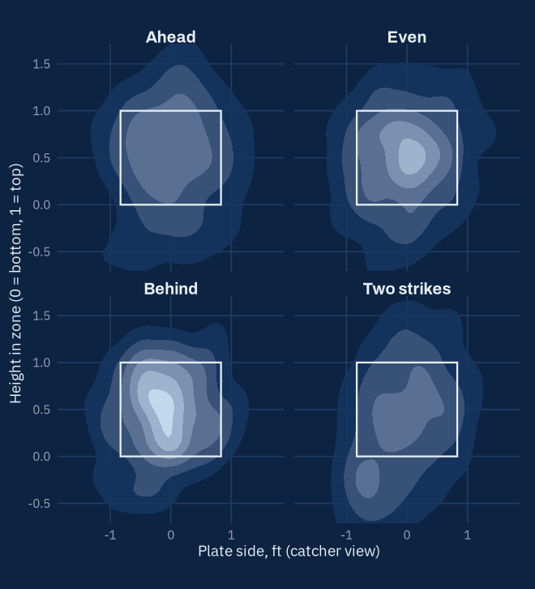

n = 2,892. Ahead 353 · even 1041 · behind 635 · two strikes 863 pitches. Box = rule-book zone.

### Put-away

The CU is 26% of two-strike pitches vs 16% overall.

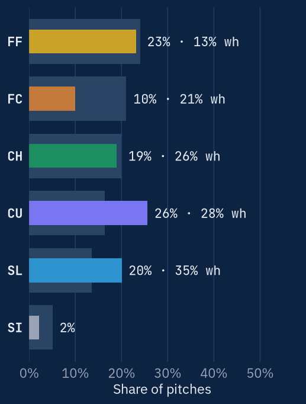

Two-strike n: CU 221, FF 200, SL 173, CH 164, FC 86, SI 19. Grey bars = overall usage; wh = whiffs per swing (shown with 50+ swings).

### Arsenal

| Pitch | # | Use | Velo | IVB | HB | VAA | Whiff | Chase | xwOBAcon | xRV/100 | Stuff+ |
| --- | --- | --- | --- | --- | --- | --- | --- | --- | --- | --- | --- |
| 4-Seam (FF) | 695 | 24% | 92.5 | 16.9 | +6.0 | -5.0 | 17% | 24% | .381 | -0.05 | 87 |
| Cutter (FC) | 609 | 21% | 89.8 | 9.3 | -2.5 | -6.2 | 21% | 34% | .324 | +0.96 | 109 |
| Changeup (CH) | 578 | 20% | 81.0 | 9.7 | +12.6 | -7.8 | 36% | 28% | .327 | +0.35 | 107 |
| Curveball (CU) | 472 | 16% | 81.7 | -9.3 | -3.7 | -9.6 | 29% | 26% | .341 | -0.33 | 86 |
| Slider (SL) | 391 | 14% | 85.2 | 3.0 | -3.3 | -8.2 | 35% | 42% | .457 | -0.40 | 100 |
| Sinker (SI) | 147 | 5% | 91.5 | 11.1 | +12.6 | -6.3 | 8% | 19% | .387 | -0.25 | 85 |

IVB / HB in inches (HB + = arm side). VAA in degrees at the front of the plate. xRV/100 = expected run value per 100 pitches, pitcher’s view, shrunk with a 250-pitch prior. Stuff+ = this project’s shape-only model (100 = MLB average, 10 = 1 SD).

### Vs. batter hand

| Pitch | LHH # | Use | Whiff | xwOBAcon | RHH # | Use | Whiff | xwOBAcon |
| --- | --- | --- | --- | --- | --- | --- | --- | --- |
| FF | 166 | 23% | 18% | .401 | 529 | 24% | 17% | .365 |
| FC | 124 | 17% | 16% | .343 | 485 | 22% | 22% | .319 |
| CH | 53 | 7% | – | .305 | 525 | 24% | 36% | .283 |
| CU | 84 | 12% | – | .145 | 388 | 18% | 27% | .255 |
| SL | 185 | 26% | 35% | .324 | 206 | 9% | 34% | .296 |
| SI | 105 | 15% | – | .318 | 42 | 2% | – | .483 |

Use = share of pitches to that side. Whiff = whiffs per swing, shown with 50+ swings.